# HHTS: transit ridership (2017, 2019, 2021) Analysis

Mary Richards

July 28, 2022

# Introduction

The work presented in this document contains analysis of commute mode, with a focus on transit ridership, in relation to auto ownership and geography. The analysis includes 2021 data and utilizes PSRC’s R package, [psrc.travelsurvey](https://psrc.github.io/psrc.travelsurvey/index.html).

- **Has commuting by transit changed with COVID-19?** (2017 and 2019 vs. 2021)
  - Who uses transit? Have there been shifts over time?
- **How does vehicle ownership influence transit commuting use over time?**

*Filtering out children and those who do not commute*

# General Commuting

Using ‘commute_mode’ defined as: ‘Usual way of commuting to current location/office’  
*survey logic*: if workplace = fixed/varied/telework some days

Workplace options:

- **Only one work location outside of home**
- Work at home ONLY (telework, self-employed)
- **Telework some days and travel to a work location some days**
- **Work location regularly varies (different offices/jobsites)**
- Drive/travel for work (driver, sales)

```
##
##                                                                                   2017
##   Airplane or helicopter                                                             8
##   Bicycle or e-bike                                                                156
##   Bus (public transit)                                                             842
##   Carpool ONLY with other household members                                        187
##   Carpool with other people not in household (may also include household members)   70
##   Commuter rail (Sounder, Amtrak)                                                   13
##   Drive alone                                                                     1728
##   Ferry or water taxi                                                                6
##   Motorcycle/moped                                                                   0
##   Motorcycle/moped/scooter                                                          12
##   Other (e.g. skateboard)                                                            2
##   Other hired service (Uber, Lyft, or other smartphone-app car service)             10
##   Paratransit                                                                        1
##   Private bus or shuttle                                                            22
##   Scooter or e-scooter (e.g., Lime, Bird, Razor)                                     0
##   Streetcar                                                                          3
##   Taxi (e.g., Yellow Cab)                                                            1
##   Urban rail (Link light rail, monorail)                                            95
##   Urban rail (Link light rail, monorail, streetcar)                                  0
##   Vanpool                                                                           28
##   Walk, jog, or wheelchair                                                         286
##
##                                                                                   2017_2019
##   Airplane or helicopter                                                                 14
##   Bicycle or e-bike                                                                     322
##   Bus (public transit)                                                                 1600
##   Carpool ONLY with other household members                                             337
##   Carpool with other people not in household (may also include household members)       132
##   Commuter rail (Sounder, Amtrak)                                                        48
##   Drive alone                                                                          3169
##   Ferry or water taxi                                                                    32
##   Motorcycle/moped                                                                       12
##   Motorcycle/moped/scooter                                                               12
##   Other (e.g. skateboard)                                                                 2
##   Other hired service (Uber, Lyft, or other smartphone-app car service)                  34
##   Paratransit                                                                             1
##   Private bus or shuttle                                                                 54
##   Scooter or e-scooter (e.g., Lime, Bird, Razor)                                          3
```

[output cut: 37 more lines]

```
##   Drive alone                                                                     1128
##   Ferry or water taxi                                                                8
##   Motorcycle/moped                                                                   0
##   Motorcycle/moped/scooter                                                           7
##   Other (e.g. skateboard)                                                            0
##   Other hired service (Uber, Lyft, or other smartphone-app car service)              4
##   Paratransit                                                                        2
##   Private bus or shuttle                                                             1
##   Scooter or e-scooter (e.g., Lime, Bird, Razor)                                     5
##   Streetcar                                                                          0
##   Taxi (e.g., Yellow Cab)                                                            0
##   Urban rail (Link light rail, monorail)                                             0
##   Urban rail (Link light rail, monorail, streetcar)                                 12
##   Vanpool                                                                            2
##   Walk, jog, or wheelchair                                                          43
```

When the commute modes are simplified:

```
##
##                                   2017 2017_2019 2019 2021
##   1-Active transit/micro mobility  454       996  542   84
##   2-Public Transit                 960      1913  953  144
##   3-Drive alone                   1728      3169 1441 1128
##   4-HOV modes                      296       558  262  128
##   5-Other modes                     32        70   38    2
```

HOV-modes are categorized based on the number of individuals in the vehicle:

- “Carpool ONLY with other household members”
- “Carpool with other people not in household (may also include household members)”
- “Other hired service (Uber, Lyft, or other smartphone-app car service)”
- “Taxi (e.g., Yellow Cab)”
- “Vanpool”

## Race/ethnicity

### Race - all categories

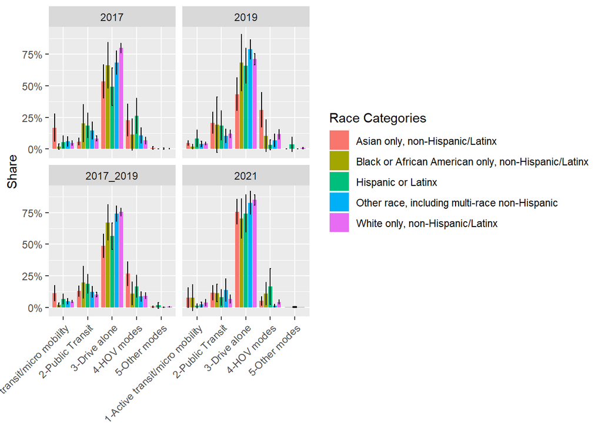

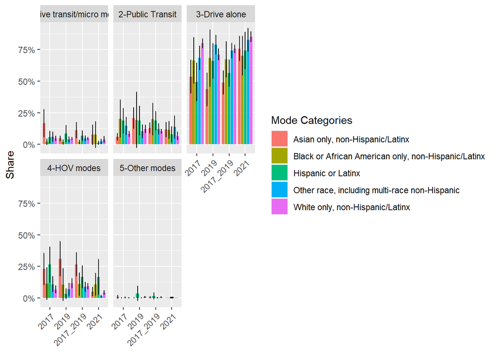

#### Focusing on Active/Public Transit

To look at numbers more closely

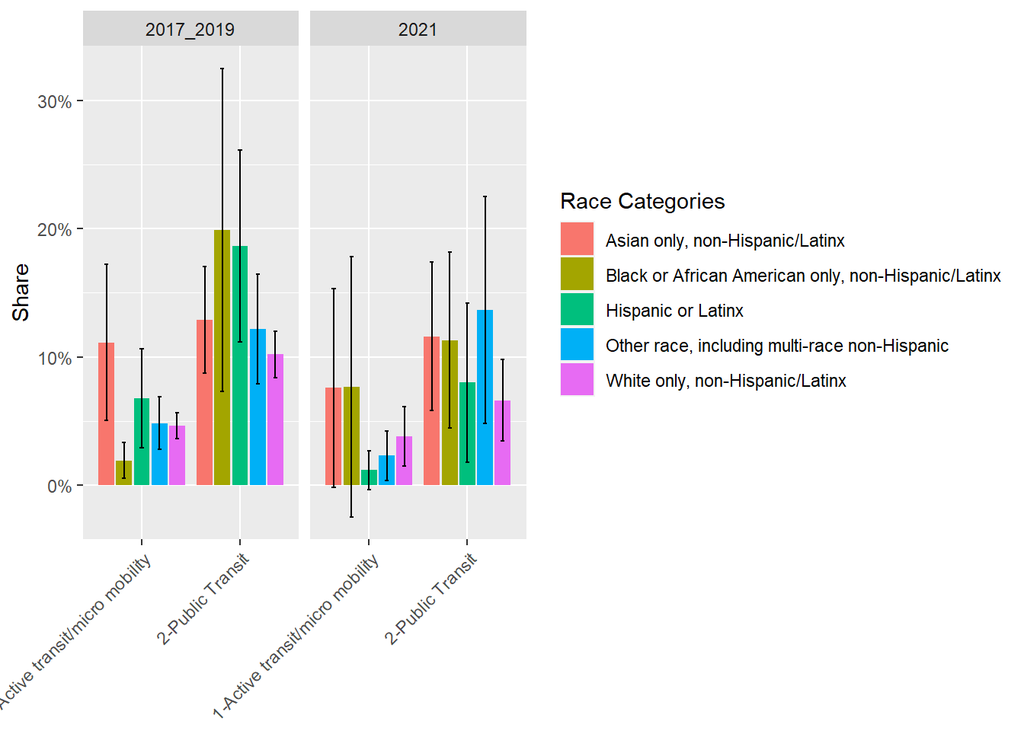

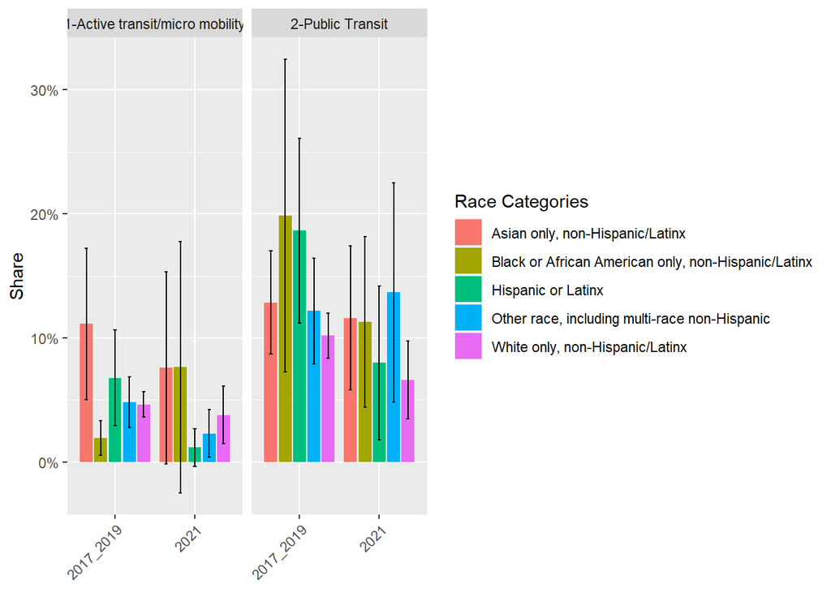

### Race - POC/Non-POC

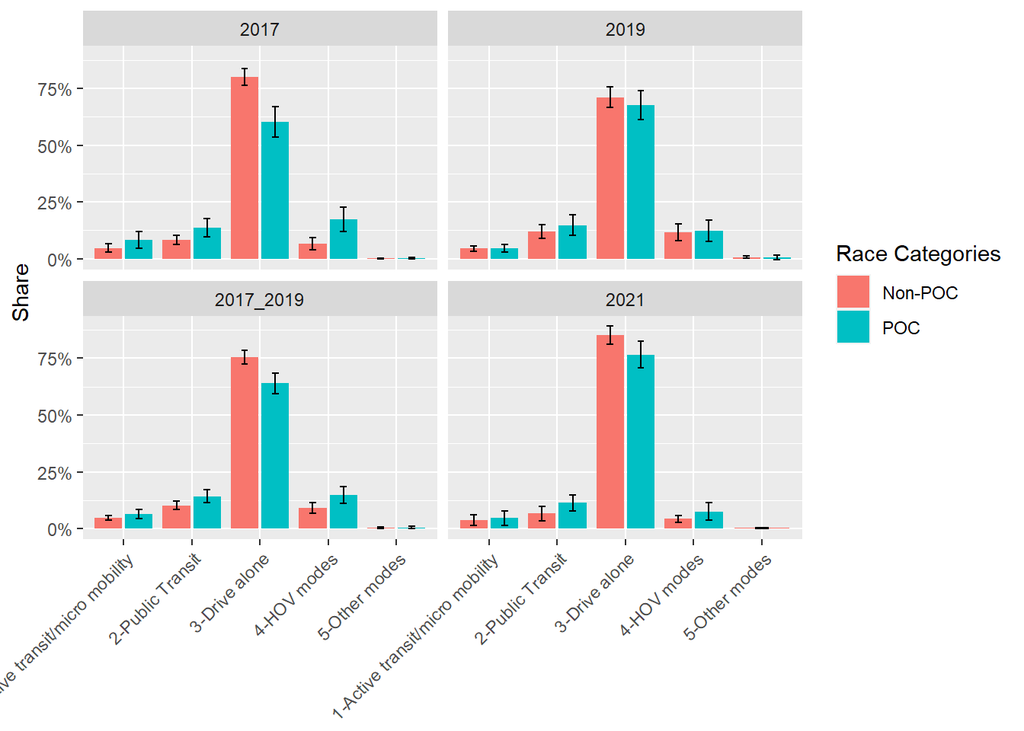

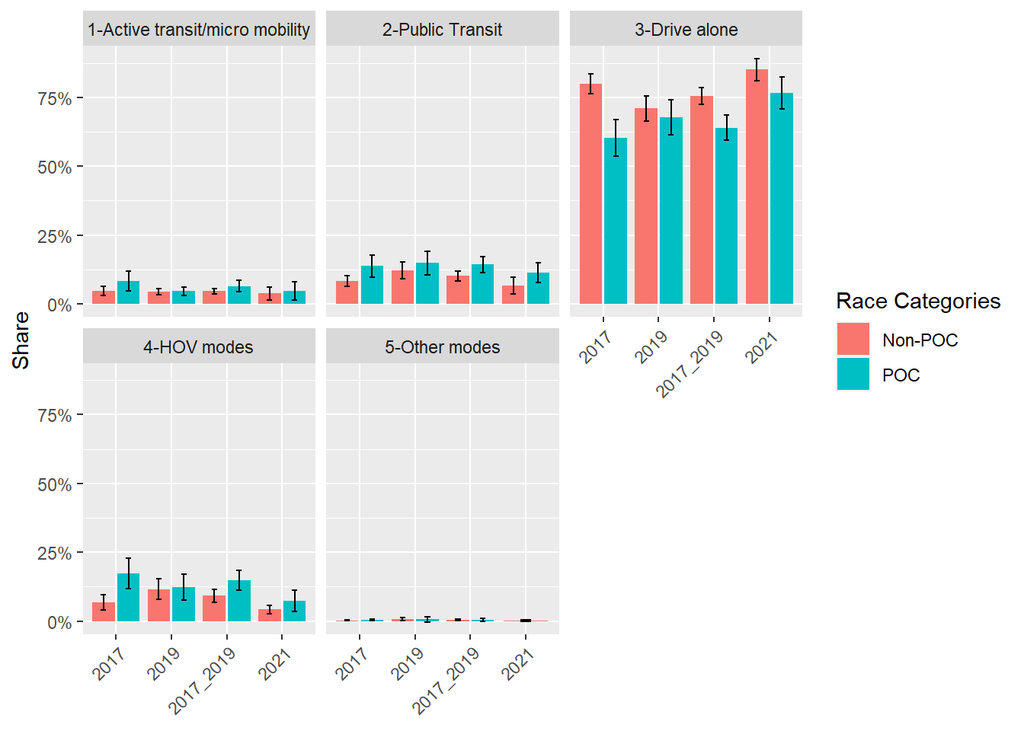

#### Focusing on Active/Public Transit

To look at numbers more closely

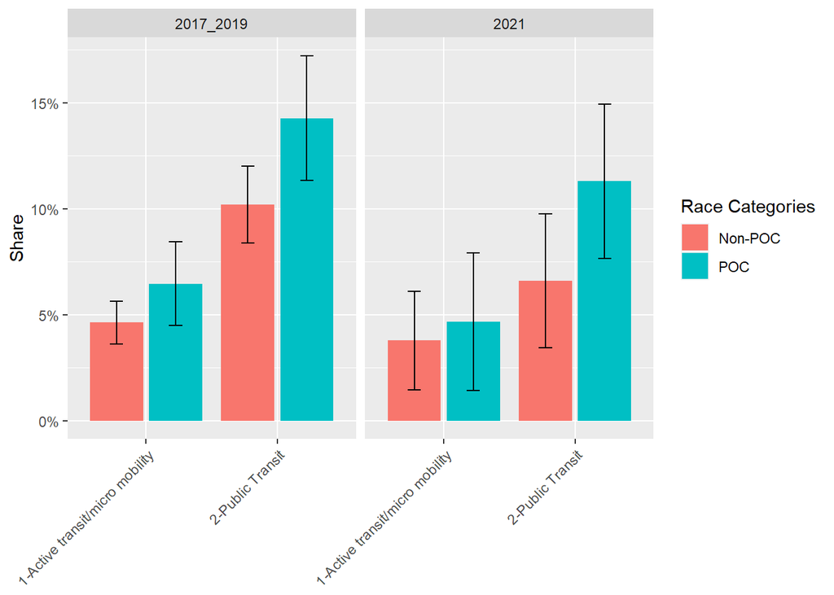

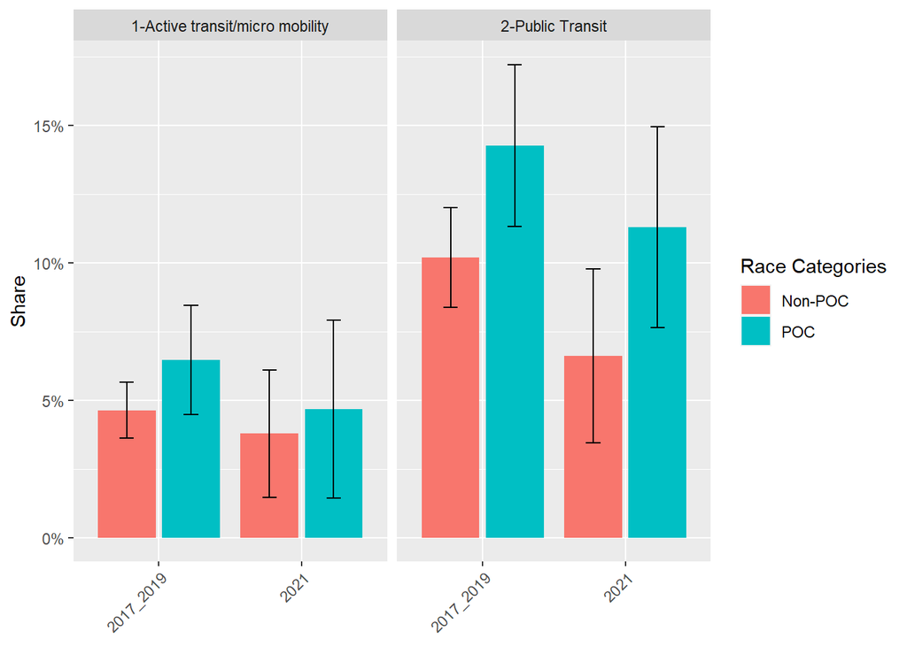

### Race - Asian POC/Non-Asian POC/White

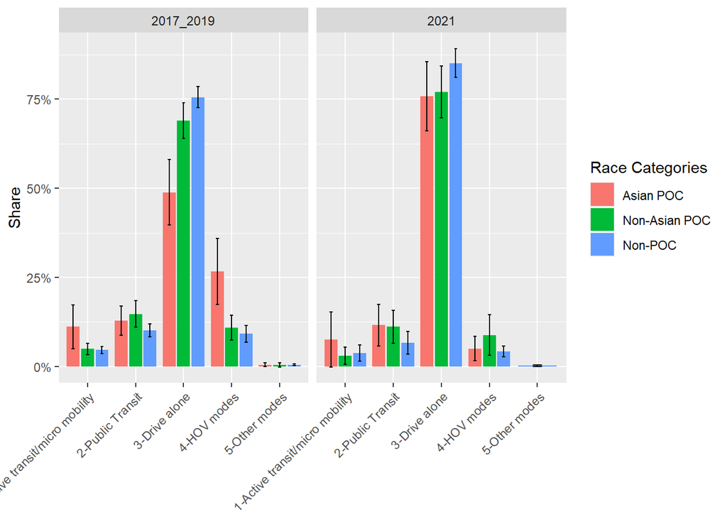

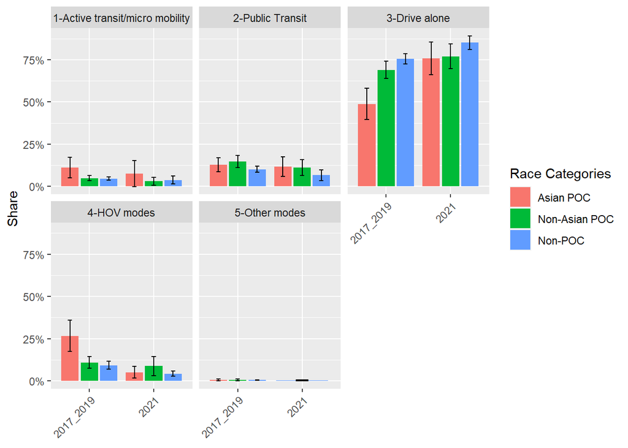

#### Focusing on Active/Public Transit

To look at numbers more closely

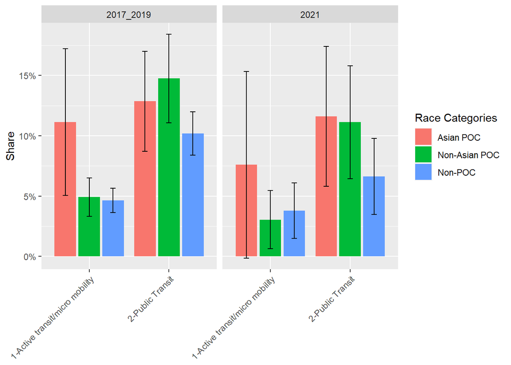

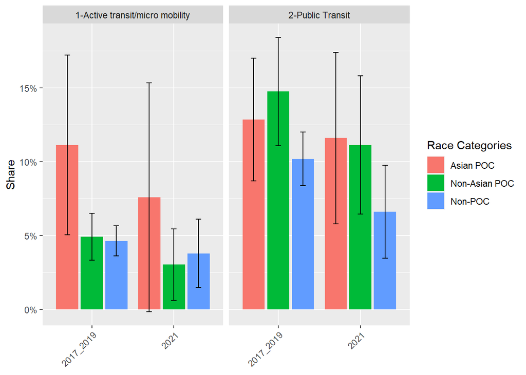

## Income

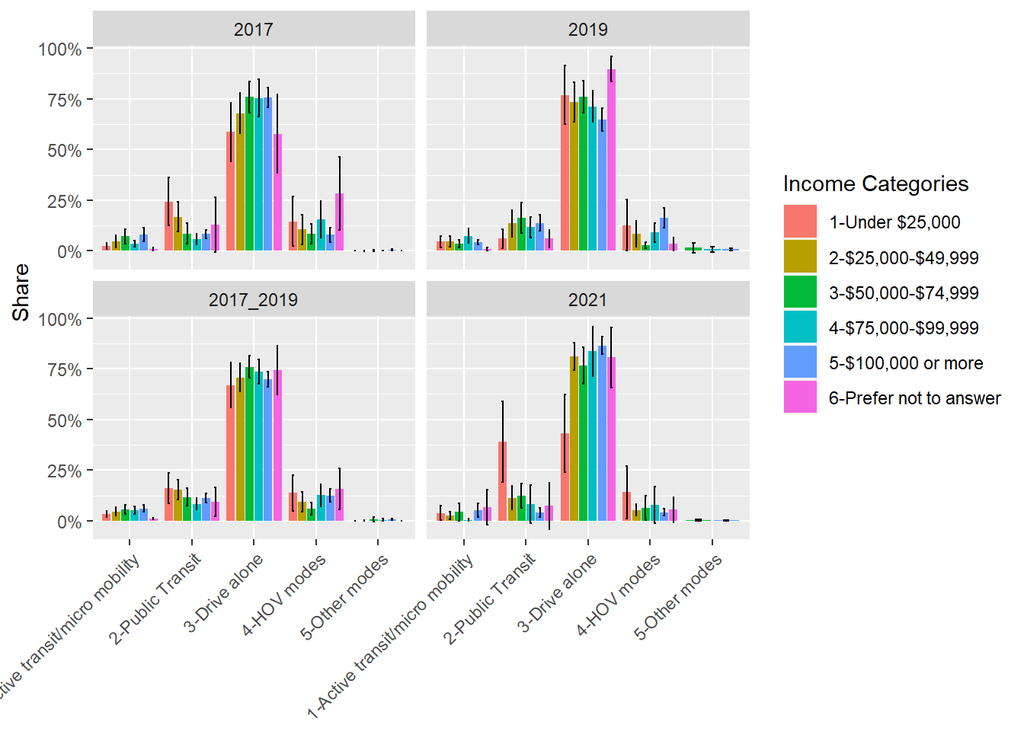

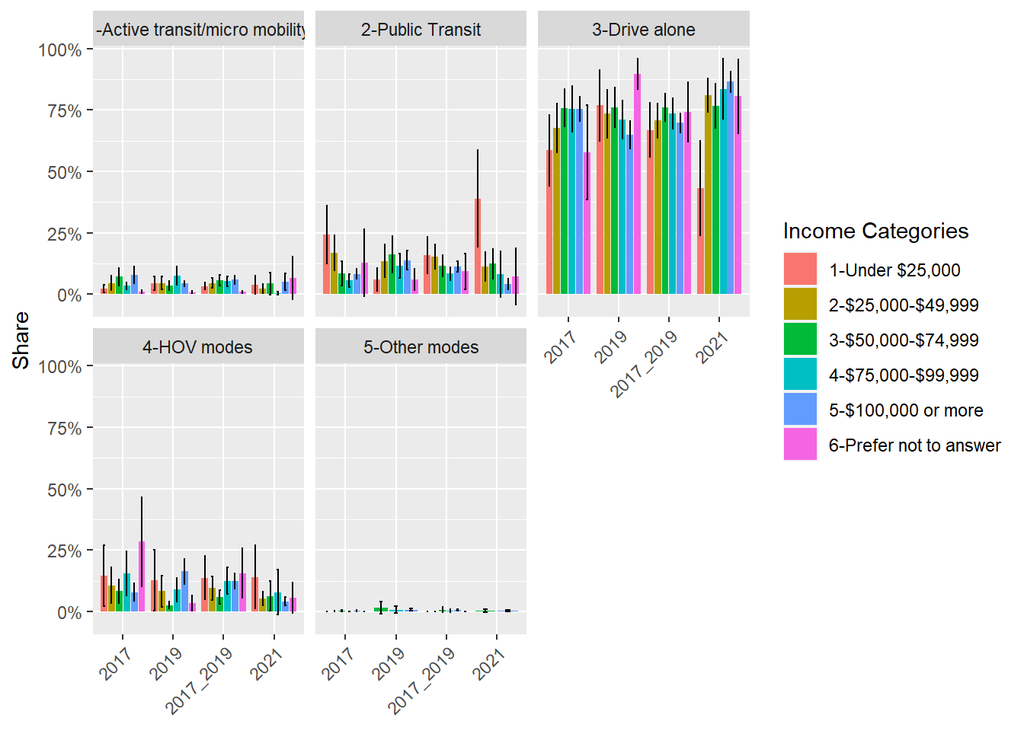

#### Focusing on Active/Public Transit

To look at numbers more closely

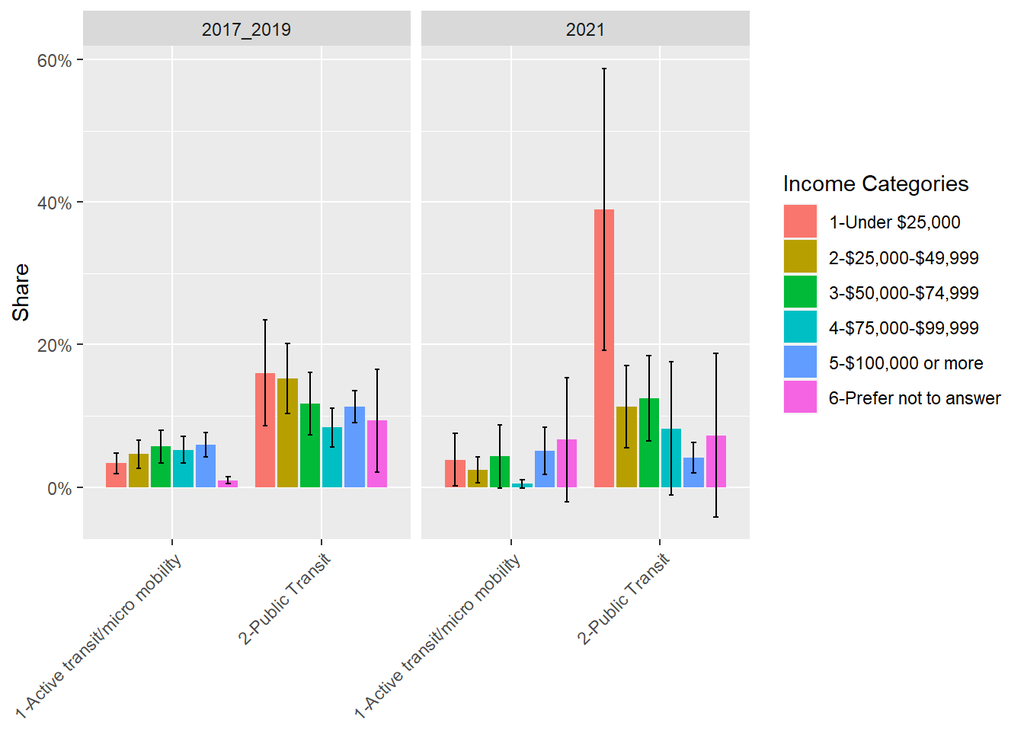

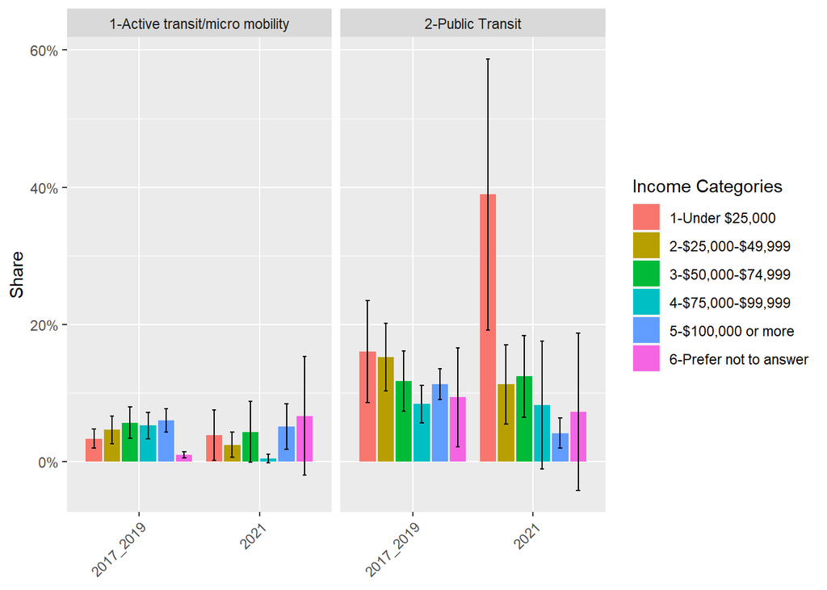

## Education

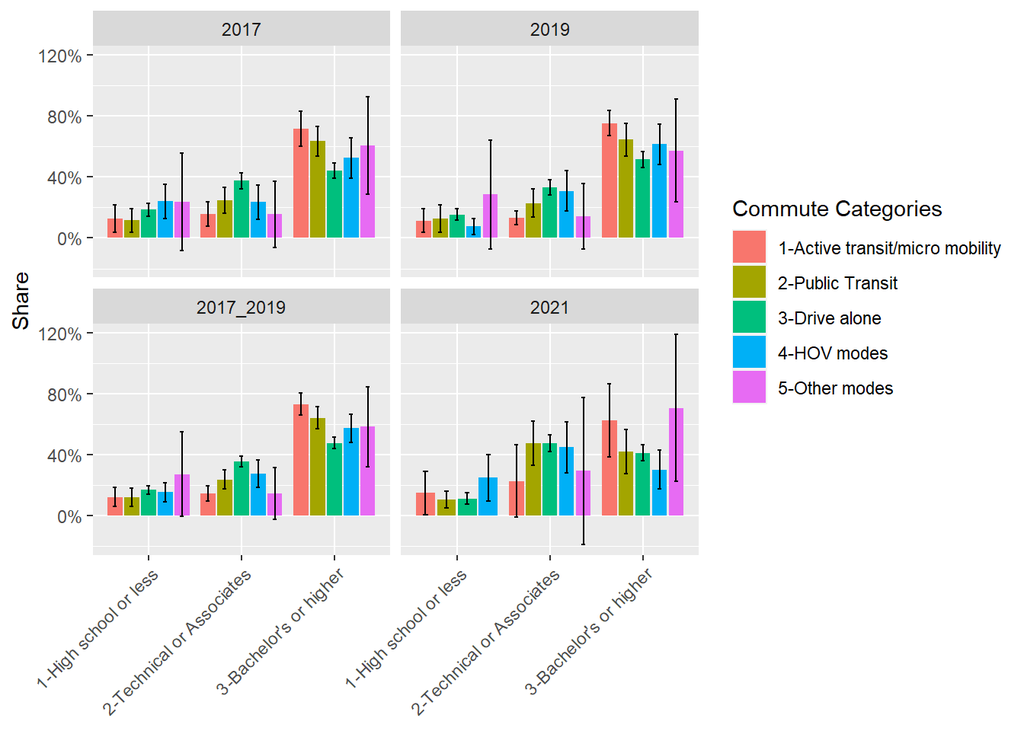

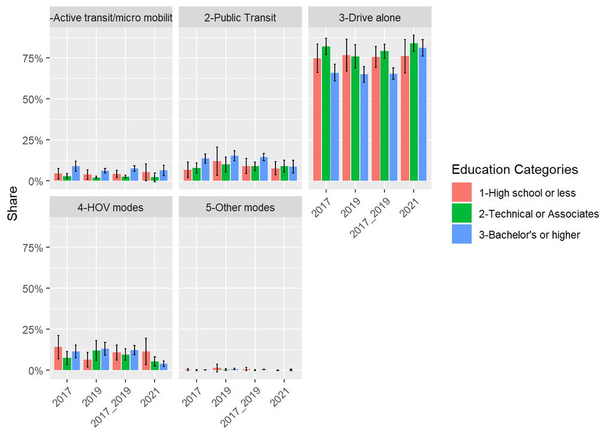

#### Focusing on Active/Public Transit

To look at numbers more closely

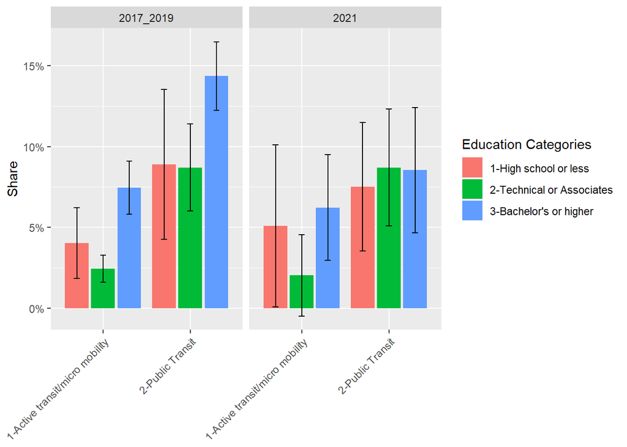

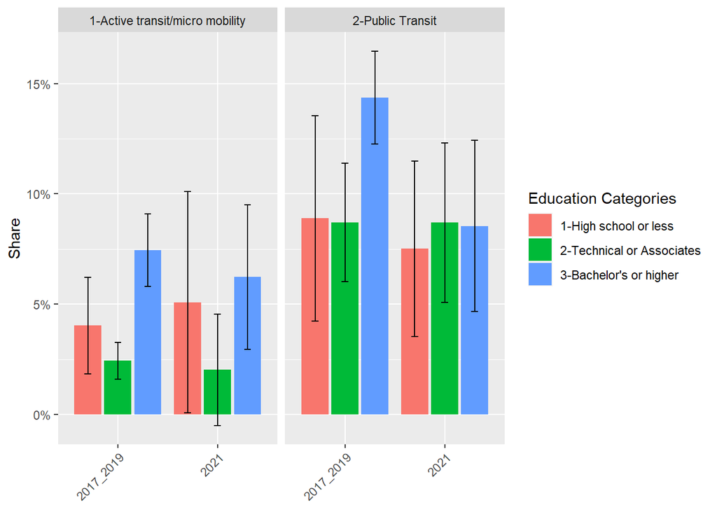

## Regional Growth Center

This analysis is based on the *final_home_is_rgc* variable.

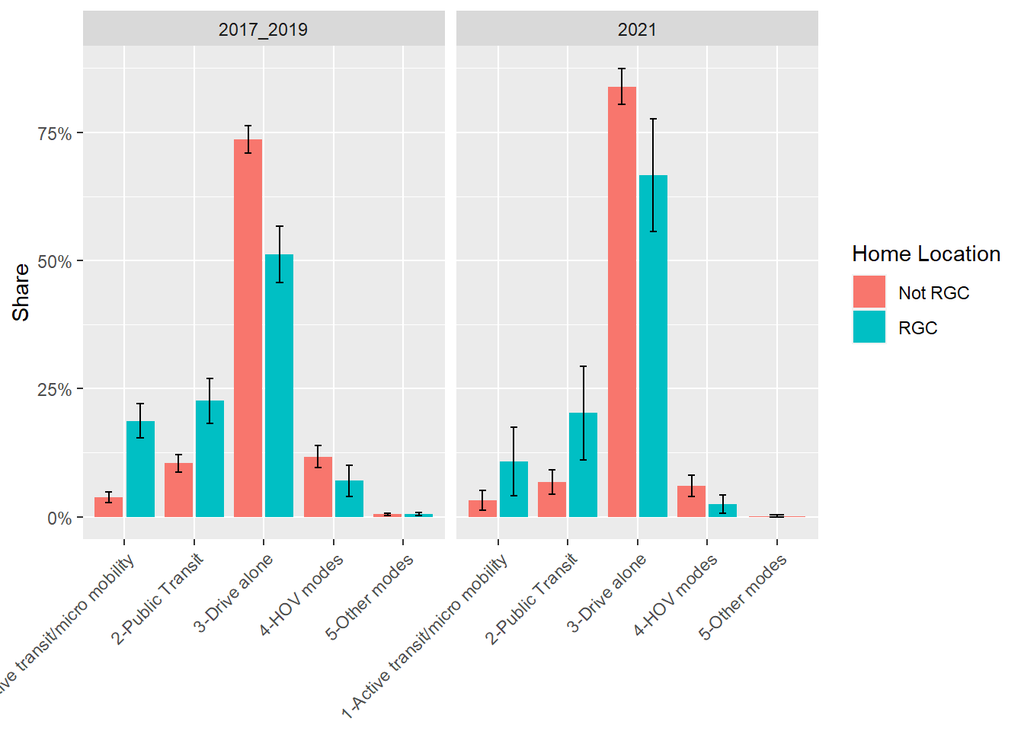

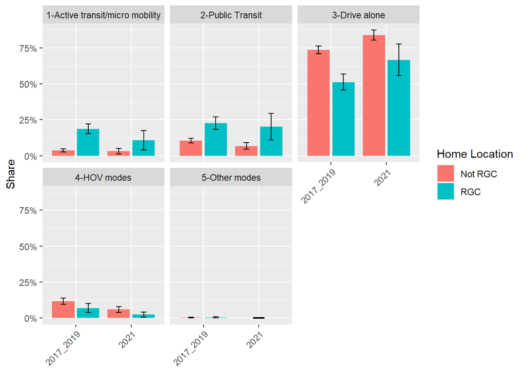

#### Focusing on Active/Public Transit

To look at numbers more closely

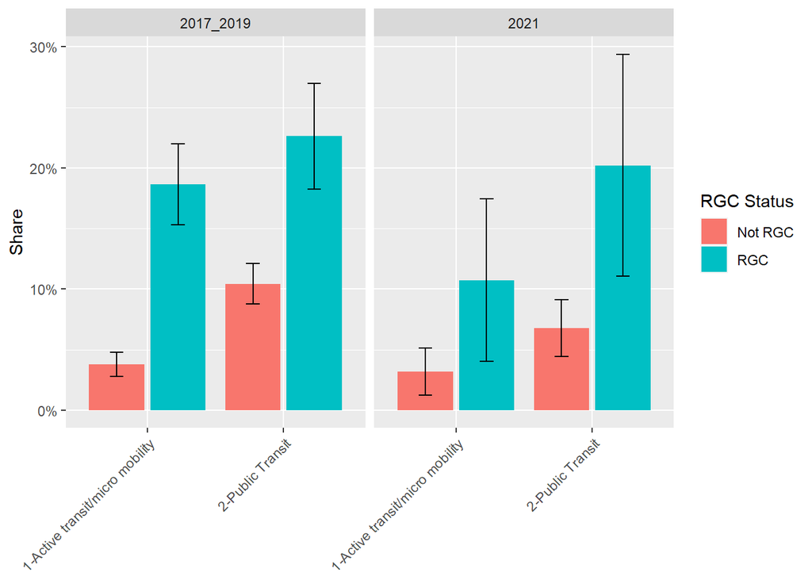

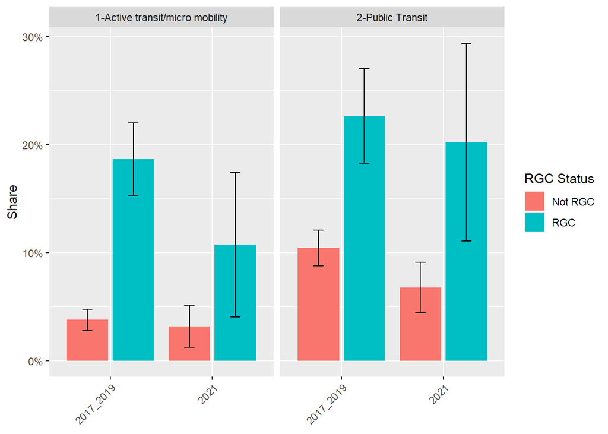

# No-vehicle households

The following research will be focused on those who reported commuting to work and who don’t own any hosehold vehicles.

survey logic: vehicle_count==“0 (no vehicles)”

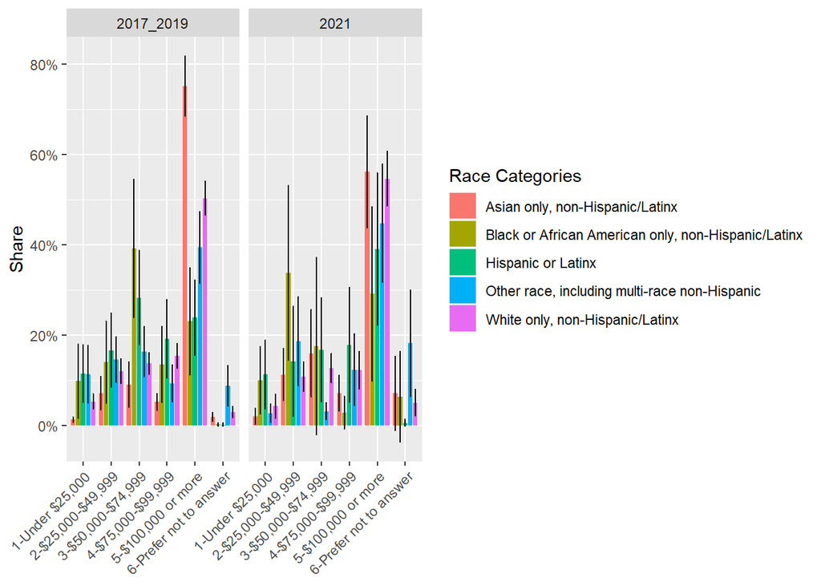

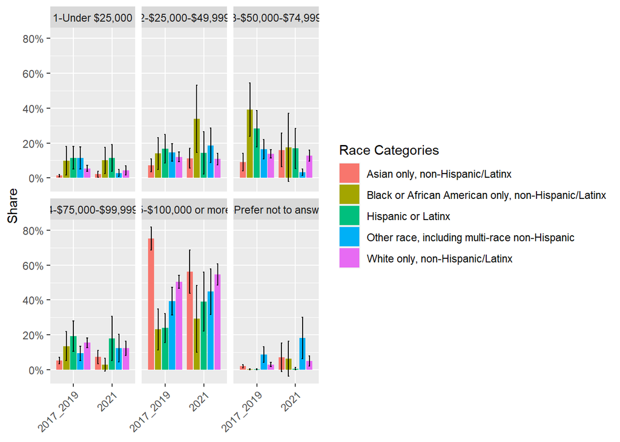

## Race/ethnicity

### Race - all categories

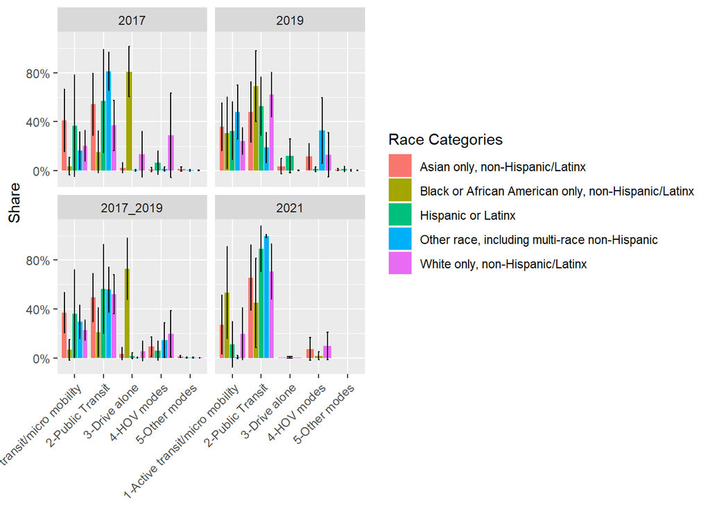

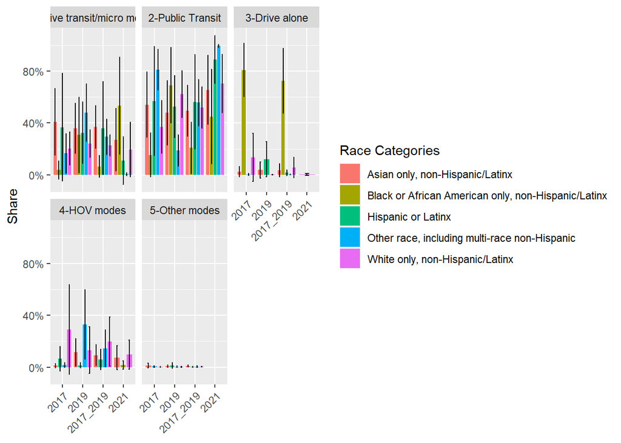

#### Focusing on Active/Public Transit

To look at numbers more closely

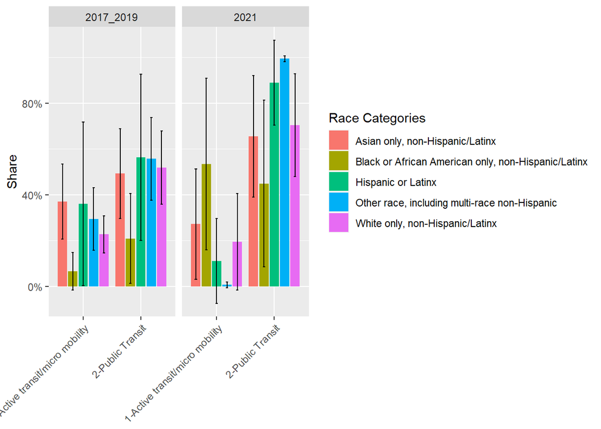

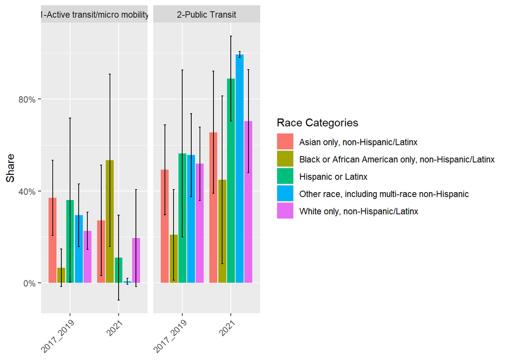

### Race - POC/Non-POC

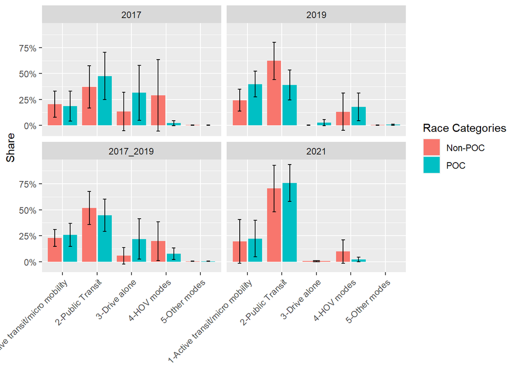

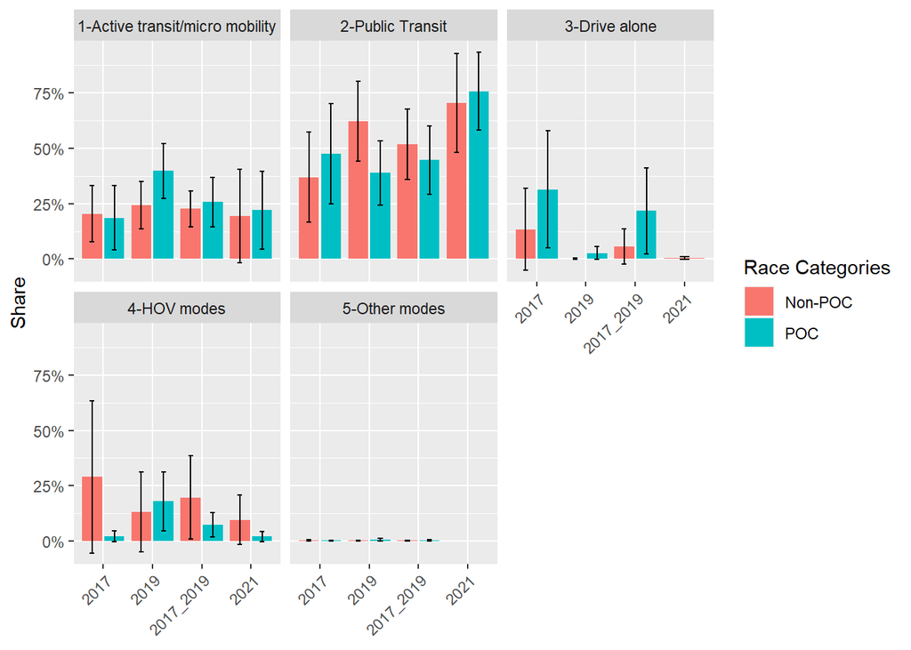